# STAT508_DAA7

Ada Lazuli

Tuesday, March 17, 2026

## Front Matter

```r
#Delete all objects from Environment - Use with caution
remove(list = ls())

#Load Libraries
library(tidyverse)
library(gridExtra)
library(splines)
library(mgcv)
library(reactable)

#Read in Boston Housing Data
biolum <- read.csv("../../sample_data/L07_Biolum.csv")
```

## Problem 1 - Initial Exploration

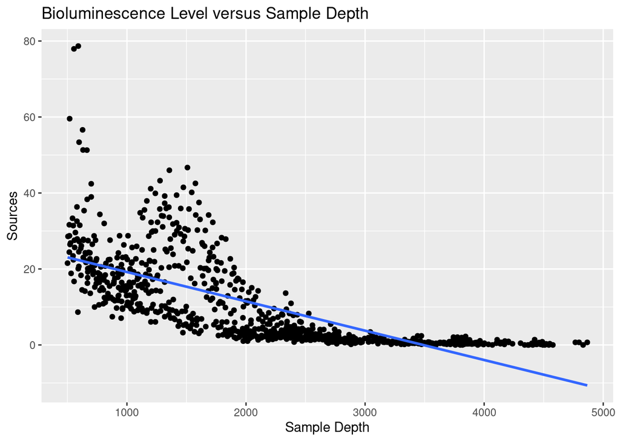

```r
ggplot(biolum, aes(x = SampleDepth, y = Sources)) +
  geom_point() +
  geom_smooth(method = "lm", se = FALSE) +
  labs(title = "Bioluminescence Level versus Sample Depth",
       x = "Sample Depth",
       y = "Sources")
```

It appears that as the sample depth increases, the bioluminescence decreases. The scatter plot suggests that this function is nonlinear.

#### Part b. - Create a scatterplot showing bioluminescence as a function of sample depth, and facet on season. Comment on what you have learned from the plot. As part of this, be sure to address the adjusted research question.

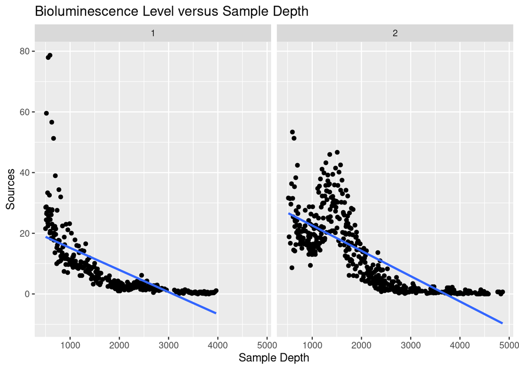

```r
ggplot(biolum, aes(x = SampleDepth, y = Sources)) +
  geom_point() +
  geom_smooth(method = "lm", se = FALSE) +
  labs(title = "Bioluminescence Level versus Sample Depth",
       x = "Sample Depth",
       y = "Sources") +
  facet_wrap(~Season)
```

This facet wrap shows that the season definitely impacts the bio-luminescence level.

## Problem 2 - Polynomial Regression

#### Part a. - Build a linear regression model for predicting bioluminescence using sample depth. Name the result model0 and display a summary of the model.

```r
model0 <- lm(Sources ~ SampleDepth, data = biolum)
summary(model0)
```

```
##
## Call:
## lm(formula = Sources ~ SampleDepth, data = biolum)
##
## Residuals:
##     Min      1Q  Median      3Q     Max
## -13.730  -5.618  -1.777   3.570  56.324
##
## Coefficients:
##               Estimate Std. Error t value Pr(>|t|)
## (Intercept) 26.9090190  0.6473273   41.57   <2e-16 ***
## SampleDepth -0.0077187  0.0002757  -28.00   <2e-16 ***
## ---
## Signif. codes:  0 '***' 0.001 '**' 0.01 '*' 0.05 '.' 0.1 ' ' 1
##
## Residual standard error: 8.305 on 787 degrees of freedom
## Multiple R-squared:  0.499,  Adjusted R-squared:  0.4983
## F-statistic: 783.7 on 1 and 787 DF,  p-value: < 2.2e-16
```

#### Part b. - Fit a degree 3 polynomial regression model (i.e., a cubic regression model) for predicting bioluminescence using sample depth. Name the result model1 and display a summary of the model.

```r
model1 <- lm(Sources ~ SampleDepth + I(SampleDepth^2) + I(SampleDepth^3), data = biolum)
summary(model1)
```

```
##
## Call:
## lm(formula = Sources ~ SampleDepth + I(SampleDepth^2) + I(SampleDepth^3),
##     data = biolum)
##
## Residuals:
##     Min      1Q  Median      3Q     Max
## -17.275  -4.497  -0.874   1.484  52.794
##
## Coefficients:
##                    Estimate Std. Error t value Pr(>|t|)
## (Intercept)       3.304e+01  2.248e+00  14.699  < 2e-16 ***
## SampleDepth      -1.166e-02  3.548e-03  -3.286  0.00106 **
## I(SampleDepth^2) -1.054e-06  1.608e-06  -0.655  0.51239
## I(SampleDepth^3)  4.670e-10  2.163e-10   2.159  0.03114 *
## ---
## Signif. codes:  0 '***' 0.001 '**' 0.01 '*' 0.05 '.' 0.1 ' ' 1
##
## Residual standard error: 7.792 on 785 degrees of freedom
## Multiple R-squared:  0.5601, Adjusted R-squared:  0.5584
## F-statistic: 333.1 on 3 and 785 DF,  p-value: < 2.2e-16
```

#### Part c. - Find the AIC for model0 and model1. (Be sure the AIC values are displayed in your Markdown document.) Which model is preferred based on the AIC values?

```r
AIC(model0)
```

```
## [1] 5583.537
```

```r
AIC(model1)
```

```
## [1] 5484.898
```

## Problem 3 - Regression Splines

#### Part a. - Using 4 equally spaced knots placed at the 20th, 40th, 60th, and 80th percentiles of SampleDepth, fit a cubic regression spline. Name the result model2 and display a summary of the model.

```r
knots <- quantile(x = biolum$SampleDepth,
                  probs = c(0.2, .4, .6, .8))
model2 <- lm(Sources ~ bs(x = SampleDepth, degree = 3, knots = knots), data = biolum)
summary(model2)
```

```
##
## Call:
## lm(formula = Sources ~ bs(x = SampleDepth, degree = 3, knots = knots),
##     data = biolum)
##
## Residuals:
##     Min      1Q  Median      3Q     Max
## -20.179  -3.007  -0.252   1.629  50.131
##
## Coefficients:
##                                                 Estimate Std. Error t value
## (Intercept)                                       38.213      1.957  19.521
## bs(x = SampleDepth, degree = 3, knots = knots)1  -23.214      3.425  -6.778
## bs(x = SampleDepth, degree = 3, knots = knots)2  -18.205      2.126  -8.564
## bs(x = SampleDepth, degree = 3, knots = knots)3  -18.148      2.604  -6.969
## bs(x = SampleDepth, degree = 3, knots = knots)4  -40.015      2.235 -17.906
## bs(x = SampleDepth, degree = 3, knots = knots)5  -32.577      3.254 -10.010
## bs(x = SampleDepth, degree = 3, knots = knots)6  -42.314      3.632 -11.649
## bs(x = SampleDepth, degree = 3, knots = knots)7  -35.567      3.848  -9.243
##                                                 Pr(>|t|)
## (Intercept)                                      < 2e-16 ***
## bs(x = SampleDepth, degree = 3, knots = knots)1 2.41e-11 ***
## bs(x = SampleDepth, degree = 3, knots = knots)2  < 2e-16 ***
## bs(x = SampleDepth, degree = 3, knots = knots)3 6.78e-12 ***
## bs(x = SampleDepth, degree = 3, knots = knots)4  < 2e-16 ***
## bs(x = SampleDepth, degree = 3, knots = knots)5  < 2e-16 ***
## bs(x = SampleDepth, degree = 3, knots = knots)6  < 2e-16 ***
## bs(x = SampleDepth, degree = 3, knots = knots)7  < 2e-16 ***
## ---
## Signif. codes:  0 '***' 0.001 '**' 0.01 '*' 0.05 '.' 0.1 ' ' 1
##
## Residual standard error: 7.309 on 781 degrees of freedom
## Multiple R-squared:  0.6149, Adjusted R-squared:  0.6114
## F-statistic: 178.1 on 7 and 781 DF,  p-value: < 2.2e-16
```

#### Part b. - Find the AIC for model2. Based on AIC, would the cubic spline model be preferred to model0 or model1? Explain.

```r
AIC(model2)
```

```
## [1] 5387.892
```

Based on the AIC values, `model2` is preferred due the lower AIC value of 5387.892 compared to AIC values of 5583.537 and 5484.898 for models `model0` and `model1`.

## Problem 4 - Generalized Additive Models

#### Part a. - Fit a GAM for predicting bioluminescence using a smooth term for sample depth and a linear term for season. Since Season is an indicator, treat it as a factor. Name the result model3 and display a summary of the model. Comment on the effective degrees of freedom of the smooth terms.

```r
biolum <- biolum %>% mutate(SeasonFactor = as.factor(Season))
model3 <- gam(Sources ~ s(SampleDepth) + SeasonFactor, data = biolum)
summary(model3)
```

```
##
## Family: gaussian
## Link function: identity
##
## Formula:
## Sources ~ s(SampleDepth) + SeasonFactor
##
## Parametric coefficients:
##               Estimate Std. Error t value Pr(>|t|)
## (Intercept)     7.2493     0.3613   20.07   <2e-16 ***
## SeasonFactor2   6.1631     0.4826   12.77   <2e-16 ***
## ---
## Signif. codes:  0 '***' 0.001 '**' 0.01 '*' 0.05 '.' 0.1 ' ' 1
##
## Approximate significance of smooth terms:
##                  edf Ref.df     F p-value
## s(SampleDepth) 8.829  8.991 184.6  <2e-16 ***
## ---
## Signif. codes:  0 '***' 0.001 '**' 0.01 '*' 0.05 '.' 0.1 ' ' 1
##
## R-sq.(adj) =  0.692   Deviance explained = 69.5%
## GCV = 42.991  Scale est. = 42.401    n = 789
```

#### Part b. - Plot the contributions of each feature.

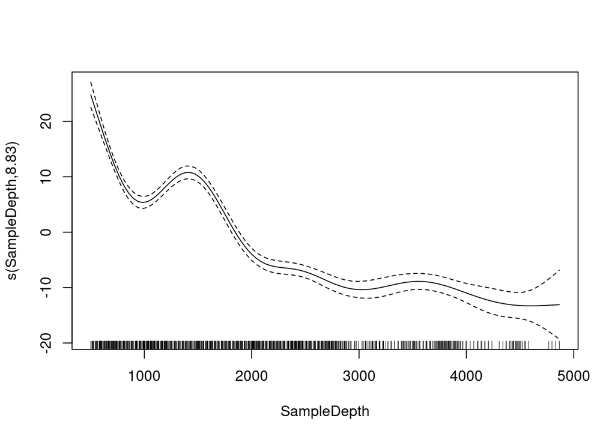

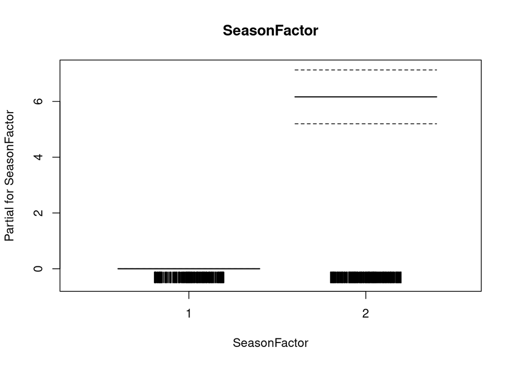

```r
plot(model3, all.terms = TRUE)
```

#### Part c. - Based on AIC values, is model3 preferred over the earlier models (models 0, 1, and 2)? Explain.

```r
AIC(model3)
```

```
## [1] 5208.362
```

Based on the AIC values, model3 has the lowest value of 5208.362 and is therefore assumed to be the best model, pending further analysis and validation set error evaluation.

#### Part d. - Suppose that we wish to build upon the model constructed in Problem 4 Part a. that contains a smooth term for sample depth and a linear term for season by adding the relative depth variable to the model. Should you use a smooth term for relative depth, a linear term for relative depth, or should it not be included at all? Justify your choice based on the generalized cross validation error (GCV).

```r
model3_smooth <- gam(Sources ~ s(SampleDepth) + s(RelativeDepth) + SeasonFactor, data = biolum, cv = FALSE)
model3_linear <- gam(Sources ~ s(SampleDepth) + RelativeDepth + SeasonFactor, data = biolum, cv = FALSE)
summary(model3_smooth)
```

```
##
## Family: gaussian
## Link function: identity
##
## Formula:
## Sources ~ s(SampleDepth) + s(RelativeDepth) + SeasonFactor
##
## Parametric coefficients:
##               Estimate Std. Error t value Pr(>|t|)
## (Intercept)     7.9408     0.3452   23.00   <2e-16 ***
## SeasonFactor2   4.9587     0.4784   10.36   <2e-16 ***
## ---
## Signif. codes:  0 '***' 0.001 '**' 0.01 '*' 0.05 '.' 0.1 ' ' 1
##
## Approximate significance of smooth terms:
##                    edf Ref.df      F p-value
## s(SampleDepth)   8.919  8.997 151.15  <2e-16 ***
## s(RelativeDepth) 8.753  8.981  20.45  <2e-16 ***
## ---
## Signif. codes:  0 '***' 0.001 '**' 0.01 '*' 0.05 '.' 0.1 ' ' 1
##
## R-sq.(adj) =  0.749   Deviance explained = 75.5%
## GCV = 35.356  Scale est. = 34.475    n = 789
```

```r
summary(model3_linear)
```

```
##
## Family: gaussian
## Link function: identity
##
## Formula:
## Sources ~ s(SampleDepth) + RelativeDepth + SeasonFactor
##
## Parametric coefficients:
##                 Estimate Std. Error t value Pr(>|t|)
## (Intercept)    9.7954541  0.6480069  15.116   <2e-16 ***
## RelativeDepth -0.0013968  0.0002969  -4.705    3e-06 ***
## SeasonFactor2  6.0485201  0.4768786  12.684   <2e-16 ***
## ---
## Signif. codes:  0 '***' 0.001 '**' 0.01 '*' 0.05 '.' 0.1 ' ' 1
##
## Approximate significance of smooth terms:
##                  edf Ref.df     F p-value
## s(SampleDepth) 8.824  8.991 132.7  <2e-16 ***
## ---
## Signif. codes:  0 '***' 0.001 '**' 0.01 '*' 0.05 '.' 0.1 ' ' 1
##
## R-sq.(adj) =    0.7   Deviance explained = 70.4%
## GCV =  41.92  Scale est. = 41.292    n = 789
```

The GCV score for the model with the smooth function wrapper for relative depth is 35.36 while the model with the linear function for relative depth has a GCV of 41.92.

Based on the GCV scores, the model with the smooth function seems superior.

## Problem 5 Estimating Test Set Error using GAMs

#### Part a. - Using a seed of 123, perform an 80/20 training/validation split.

```r
set.seed(123)
trainInd <- sample(1:nrow(biolum), floor(0.8*nrow(biolum)))
set.seed(NULL)

Train <- biolum[trainInd, ]
Validation <- biolum[-trainInd, ]
```

#### Part b. - Calculate the validation set MSE using the GAM trained on smooth terms for sample depth and relative depth and a linear term for season.

```r
model3_smooth <- gam(Sources ~ s(SampleDepth) + s(RelativeDepth) + SeasonFactor, data = Train, cv = FALSE)
model3_smooth_pred <- predict(model3_smooth, newdata = Validation)
model3_smooth_MSE <- mean((Validation$Sources - model3_smooth_pred)^2)
summary(model3_smooth)
```

```
##
## Family: gaussian
## Link function: identity
##
## Formula:
## Sources ~ s(SampleDepth) + s(RelativeDepth) + SeasonFactor
##
## Parametric coefficients:
##               Estimate Std. Error t value Pr(>|t|)
## (Intercept)     8.1140     0.3796  21.373   <2e-16 ***
## SeasonFactor2   5.1706     0.5285   9.784   <2e-16 ***
## ---
## Signif. codes:  0 '***' 0.001 '**' 0.01 '*' 0.05 '.' 0.1 ' ' 1
##
## Approximate significance of smooth terms:
##                    edf Ref.df      F p-value
## s(SampleDepth)   8.894  8.995 121.23  <2e-16 ***
## s(RelativeDepth) 8.546  8.939  15.68  <2e-16 ***
## ---
## Signif. codes:  0 '***' 0.001 '**' 0.01 '*' 0.05 '.' 0.1 ' ' 1
##
## R-sq.(adj) =  0.743   Deviance explained =   75%
## GCV = 35.301  Scale est. = 34.214    n = 631
```

```r
model3_linear <- gam(Sources ~ s(SampleDepth) + RelativeDepth + SeasonFactor, data = Train, cv = FALSE)
model3_linear_pred <- predict(model3_linear, newdata = Validation)
model3_linear_MSE <- mean((Validation$Sources - model3_linear_pred)^2)
summary(model3_linear)
```

```
##
## Family: gaussian
## Link function: identity
##
## Formula:
## Sources ~ s(SampleDepth) + RelativeDepth + SeasonFactor
##
## Parametric coefficients:
##                 Estimate Std. Error t value Pr(>|t|)
## (Intercept)   10.0593992  0.7224961   13.92  < 2e-16 ***
## RelativeDepth -0.0013386  0.0003257   -4.11 4.48e-05 ***
## SeasonFactor2  5.9785557  0.5294745   11.29  < 2e-16 ***
## ---
## Signif. codes:  0 '***' 0.001 '**' 0.01 '*' 0.05 '.' 0.1 ' ' 1
##
## Approximate significance of smooth terms:
##                  edf Ref.df     F p-value
## s(SampleDepth) 8.784  8.986 107.6  <2e-16 ***
## ---
## Signif. codes:  0 '***' 0.001 '**' 0.01 '*' 0.05 '.' 0.1 ' ' 1
##
## R-sq.(adj) =  0.695   Deviance explained =   70%
## GCV = 41.395  Scale est. = 40.622    n = 631
```

#### Part c. - How does this value compare to the GCV value for this model? Explain.

```r
df <- data.frame(Model = c("GAM Smooth Season", "GAM Linear Season"), GCV = c(35.301, 41.395), "MSE Validation" = c(round(model3_smooth_MSE, digits = 2), round(model3_linear_MSE, digits = 2)))
reactable(df, searchable = FALSE, compact = TRUE, striped = TRUE, defaultPageSize = 5, showPageSizeOptions = FALSE)
```

| Model | GCV | MSE.Validation |
| --- | --- | --- |
| GAM Smooth Season | 35.301 | 36.63 |
| GAM Linear Season | 41.395 | 44.53 |

The GAM model with the smooth function for the `RelativeDepth` feature has a GCV value of 35.301 and MSE value of 36.63. These values are lower than the GAM model with the linear function for the `RelativeDepth` feature that has a GCV value of 41.395 and MSE of 44.53.

Based on the GCV and MSE against the validation set, tt appears that the GAM with the smooth function for `RelativeDepth` is superior. In hindsight, this makes sense as the effective degrees of freedom for that term is 8.546 and implies it is non-linear.